## Part 1 Simulation

In this section, the exponential distribution in R will be investigated and compared with the Central Limit Theorem.

The exponential distribution will be simulated in R with rexp(n, lambda) where lambda is the rate parameter. The mean of exponential distribution is 1/lambda and the standard deviation is also 1/lambda. lambda was set to be 0.2 for all of the simulations.

The following shows a thousand simulation with R

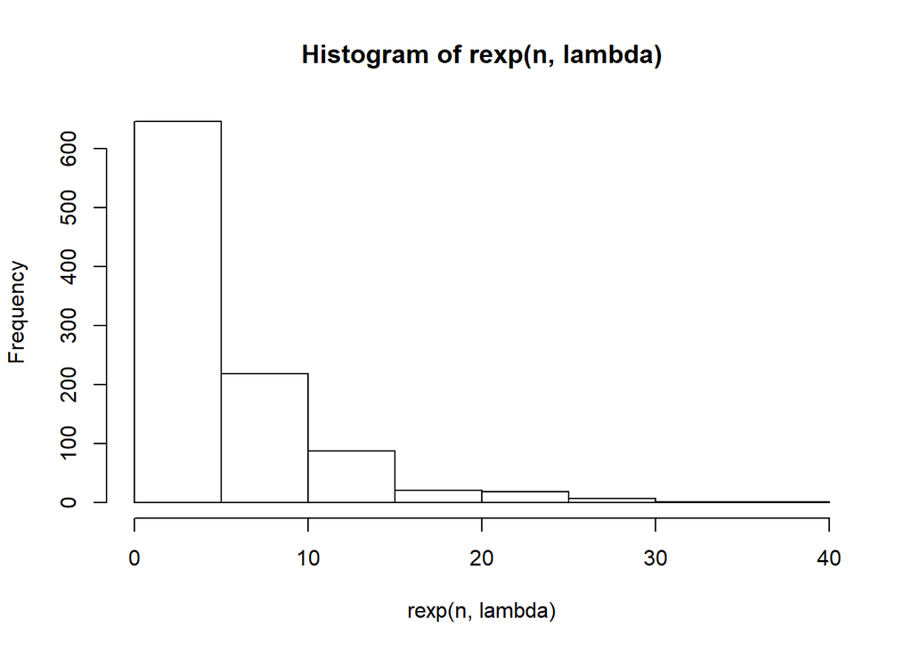

```r
    lambda = 0.2
    n = 1000
    hist(rexp(n,lambda))
```

The distribution of averages of 40 exponentials can be ploted by

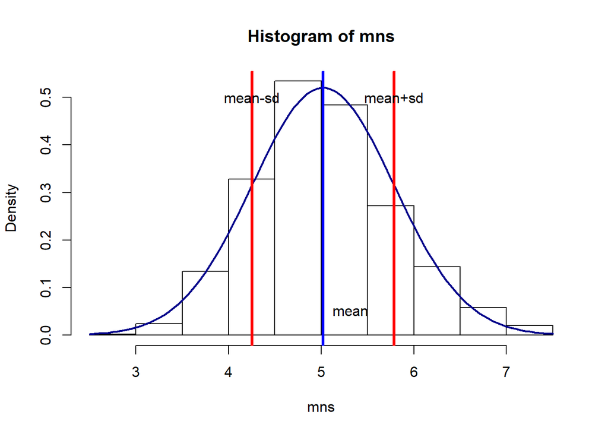

```r
    mns <- NULL
    for (i in 1:1000){
      mns <- c(mns,mean(rexp(40,lambda)))
    }
    mn <- mean(mns)
    sd <- sd(mns)

    hist(mns,freq = FALSE)
    curve(dnorm(x,mean=mn,sd=sd),col="darkblue", lwd=2, add=TRUE)
    abline(v = mn, col="blue", lwd=3)
    text(mn+0.3,0.05,"mean")
    abline(v = mn-sd, col="red", lwd=3)
    text(mn-sd,0.5,"mean-sd")
    abline(v = mn+sd, col="red", lwd=3)
    text(mn+sd,0.5,"mean+sd")
```

**The theoretical mean is 1/lambda which is 5**, and the **sample mean** is

```r
   mean(mns)
```

```
## [1] 5.018871
```

which is **the thick blue bar in the above figure**.

The theoretical standard deviation is also 1/lambda which is 5, so **the theoretical variance is 25**. The sample variance and standard deviation are

```r
  var(mns)
```

```
## [1] 0.5883208
```

```r
  sd(mns)
```

```
## [1] 0.7670207
```

respectively.

**The standard deviation is showed in two red lines with the left being mean-sd and right being mean+sd**.

The distribution is closely to a Gaussian distribution which can be seen from the figure since the histogram overlay with the gaussion distribution well.